# ESTIMACIÓN DE PARAMETROS E INTERVALOS DE CONFIANZA

FUNDAMENTOS, PROCEDIMIENTOS Y APLICACIONES EN EDUCACIÓN

Autor/a

Afiliación

Dayanne Tique Bustamante  
Paula Andrea Saldaña Cuellar  
Jorge Eliecer Riaño Duarte

[Universidad del Tolima](https://www.ut.edu.co/)

Fecha de publicación

11 de noviembre de 2026

[figure not shown]

[figure not shown]

**Ver código**

```r
options(digits = 6)
nivel <- 0.95
alpha <- 1 - nivel
z <- qnorm(1 - alpha/2)
redondear <- function(x, d = 3) round(x, d)
intervalo <- function(estimacion, margen) c(inferior = estimacion-margen, superior = estimacion+margen)
```

# 1 Fundamentos de estimación de parámetros

## 1.1 Estimación puntual

- INTRODUCCIÓN

En estadística inferencial se estudia una **población** mediante una **muestra aleatoria**. Se llama *parámetro* a una característica numérica desconocida de la población, como la media $\mu$, la proporción $p$ o la varianza $\sigma^2$. Un **estadístico** es una función de los datos muestrales. Cuando se usa para aproximar un parámetro recibe el nombre de **estimador** $\widehat\theta$; el número calculado con una muestra concreta es la **estimación**.

$$\widehat\theta=T(X_1,X_2,\ldots,X_n).$$

Por ejemplo, si se desea conocer la nota media de todos los estudiantes de una institución, la media de una muestra aleatoria es una estimación puntual de $\mu$:

$$\overline X=\frac{1}{n}\sum_{i=1}^n X_i.$$

La estimación puntual es sencilla, pero no expresa directamente la incertidumbre muestral. Esa limitación motiva los intervalos de confianza.

- PROPIEDADES DE LOS ESTIMADORES

**A. Insesgadez.** Un estimador es insesgado si su esperanza coincide con el parámetro:

$$\operatorname E(\widehat\theta)=\theta.$$

Para una muestra aleatoria con media $\mu$ y varianza finita $\sigma^2$, se cumple $\operatorname E(\overline X)=\mu$. Para la varianza conviene distinguir:

$$s_n^2=\frac1n\sum_{i=1}^n(X_i-\overline X)^2,\qquad S^2=\frac1{n-1}\sum_{i=1}^n(X_i-\overline X)^2.$$

El primero es sesgado, pues $\operatorname E(s_n^2)=\frac{n-1}{n}\sigma^2$; el segundo es insesgado, pues $\operatorname E(S^2)=\sigma^2$.

**B. Consistencia.** Un estimador es consistente cuando se acerca al parámetro al crecer la muestra:

$$\widehat\theta_n\xrightarrow{P}\theta,\qquad\text{equivalentemente}\quad
\lim_{n\to\infty}P(|\widehat\theta_n-\theta|>\varepsilon)=0\quad(\varepsilon>0).$$

Una condición **suficiente**, aunque no necesaria, es que $\operatorname E(\widehat\theta_n)\to\theta$ y $\operatorname{Var}(\widehat\theta_n)\to0$. En particular, $\operatorname{Var}(\overline X)=\sigma^2/n\to0$.

**C. Eficiencia.** Entre estimadores insesgados de un mismo parámetro, y bajo condiciones comparables, se prefiere el de menor varianza. Para dos estimadores:

$$\operatorname{Var}(\widehat\theta_1)<\operatorname{Var}(\widehat\theta_2)\ \Longrightarrow\ \widehat\theta_1\text{ es más eficiente}.$$

**Importante:** un estimador con varianza menor puede tener más sesgo. Si los estimadores son sesgados, resulta útil comparar el error cuadrático medio $\operatorname{ECM}(\widehat\theta)=\operatorname{Var}(\widehat\theta)+\operatorname{Sesgo}(\widehat\theta)^2$.

- MÉTODOS DE CÁLCULO ESTIMADORES

**A. Método de los momentos.** Se igualan los momentos teóricos de una distribución a los momentos de la muestra y se despejan los parámetros. Si $X$ es Bernoulli$(p)$, $\operatorname E(X)=p$, por lo que:

$$\widehat p_{\mathrm{MM}}=\overline X.$$

**B. Máxima verosimilitud.** Se busca el valor del parámetro que hace más probables los datos observados. Si las observaciones son independientes:

$$L(\theta)=\prod_{i=1}^n f(x_i;\theta),\qquad
\ell(\theta)=\log L(\theta).$$

Para un máximo interior diferenciable se busca una solución de $\ell'(\theta)=0$ y se comprueba que sea un máximo; también hay que considerar los límites del espacio paramétrico. Para una muestra Bernoulli:

$$L(p)=p^{\sum x_i}(1-p)^{n-\sum x_i},$$
$$\ell'(p)=\frac{\sum x_i}{p}-\frac{n-\sum x_i}{1-p}=0
\quad\Longrightarrow\quad \widehat p_{\mathrm{MV}}=\frac{\sum x_i}{n}.$$

Los estimadores de máxima verosimilitud suelen ser consistentes, asintóticamente normales y eficientes **bajo condiciones de regularidad**. La propiedad de invariancia indica que si $\widehat\theta$ maximiza la verosimilitud, $g(\widehat\theta)$ estima por máxima verosimilitud $g(\theta)$, con las condiciones pertinentes.

**Ver código**

```r
# Ejemplo: 18 de 30 estudiantes completan una actividad
respuestas <- c(rep(1, 18), rep(0, 12))
mean(respuestas) # momentos y máxima verosimilitud: p estimada = 0.60
```

```
[1] 0.6
```

## 1.2 Estimación por intervalos de confianza

Un intervalo de confianza (IC) es un procedimiento que produce dos límites a partir de los datos: $[L(X),U(X)]$. Su **nivel de confianza** $1-\alpha$ describe la cobertura del procedimiento en repeticiones del muestreo:

$$P_\theta\big(L(X)\le\theta\le U(X)\big)=1-\alpha.$$

Por ejemplo, el 95 % significa que, si se repite el muestreo muchas veces y se construye el IC del mismo modo, aproximadamente 95 de cada 100 intervalos contendrán el parámetro verdadero. **No** significa que, después de observar la muestra, el parámetro fijo tenga una probabilidad del 95 % de estar dentro de ese intervalo.

Para intervalos simétricos se utiliza:

$$IC=\text{estimación puntual}\ \pm\ \text{valor crítico}\times\text{error estándar}.$$

El **margen de error** $E$ es la semiamplitud: $E=(U-L)/2$. Se emplean las distribuciones normal estándar $Z$, $t$ de Student, ji-cuadrado $\chi^2$ o $F$, según el parámetro y los supuestos. En este material $z_{1-\alpha/2}=\Phi^{-1}(1-\alpha/2)$ y $t_{1-\alpha/2,\nu}$ es el cuantil acumulado correspondiente.

- CASOS PARTICULARES: Mapa de selección

| Parámetro | Situación | Distribución |
| --- | --- | --- |
| Media μ | σ conocida | Normal Z |
| Media μ | σ desconocida | t de Student |
| Proporción p | Aproximación de muestra grande | Normal Z |
| Varianza σ² | Población normal | χ² |
| Diferencia μ₁ − μ₂ | Varianzas conocidas | Normal Z |
| Diferencia μ₁ − μ₂ | Varianzas desconocidas e iguales | t agrupada |
| Diferencia μ₁ − μ₂ | Varianzas desconocidas y distintas | t de Welch |
| Diferencia p₁ − p₂ | Dos muestras independientes grandes | Normal Z |
| Media de diferencias pareadas | Mediciones antes/después | t pareada |

- CONDICIONES Y PRECAUCIONES

La selección aleatoria y la independencia son fundamentales. Para medias, la distribución normal de la población permite inferencia exacta con $t$ (si se desconoce la varianza); con muestras grandes puede utilizarse una aproximación por el teorema central del límite. Para proporciones, los intervalos de tipo Wald presentados en la hoja de fórmulas son aproximados y pueden funcionar mal en muestras pequeñas o proporciones extremas. Para varianzas, la normalidad de la población es especialmente importante. Para datos antes/después, deben analizarse las **diferencias dentro de cada estudiante**, no tratar las dos mediciones como grupos independientes.

- PRECISIÓN Y TAMAÑO DE LA MUESTRA

En general, aumentar el nivel de confianza ensancha el IC; aumentar $n$ disminuye el error estándar. Para estimar una media con desviación poblacional conocida y margen de error máximo $E$:

$$E=z_{1-\alpha/2}\frac{\sigma}{\sqrt n},\qquad
n=\left\lceil\left(\frac{z_{1-\alpha/2}\sigma}{E}\right)^2\right\rceil.$$

Para una proporción, usando un valor de planificación $p_0$:

$$n=\left\lceil\frac{z_{1-\alpha/2}^2p_0(1-p_0)}{E^2}\right\rceil.$$

Si no se conoce $p_0$, elegir $0.5$ produce un tamaño conservador bajo muestreo aleatorio simple. Cuando $\sigma$ es desconocida, el cálculo con $t$ depende de $n$ y puede resolverse iterativamente usando una desviación piloto. Estas expresiones no incorporan corrección por población finita, diseño complejo ni pérdidas por no respuesta.

**Ver código**

```r
# Planeación educativa: precisión de 3 puntos en una prueba,
# sigma estimada previamente en 12 puntos, confianza del 95 %
ceiling((qnorm(0.975)*12/3)^2)
```

```
[1] 62
```

**Ver código**

```r
# Proporción con error de 5 puntos porcentuales
ceiling(qnorm(0.975)^2*0.5*0.5/0.05^2)
```

```
[1] 385
```

# 2 Ejemplos de intervalos de confianza en educación

## 2.1 Ejemplos de intervalos de confianza aplicados a la educación

A continuación, se presentan ocho ejemplos prácticos de intervalos de confianza contextualizados en el ámbito educativo. Cada ejercicio se desarrolla con un nivel de confianza del 95 % e incluye el planteamiento de la situación, la fórmula estadística correspondiente, el procedimiento de cálculo, la interpretación de los resultados y su representación gráfica.

**Para visualizar el desarrollo de cada ejercicio, haga clic sobre el ejemplo de su interés.**

**NotaEjemplo 1. Media con varianza poblacional conocida**

**Situación.** Un distrito educativo desea estimar el puntaje medio de comprensión lectora. Se selecciona una muestra aleatoria de 100 estudiantes. Se supone conocida una desviación estándar poblacional de 12 puntos.

**Fórmula:**

$$IC_{\mu}=\overline{x}\pm z_{1-\alpha/2}
\frac{\sigma}{\sqrt{n}}$$

**Procedimiento y sustitución:**

**Ver código**

```r
set.seed(101)

n <- 100
sigma <- 12
datos <- rnorm(n, 72, sigma)

xbar <- mean(datos)
margen <- z*sigma/sqrt(n)
ic <- intervalo(xbar, margen)

paso(sprintf(
  "\\bar{x}=%.3f,\\quad \\sigma=%.0f,\\quad n=%d",
  xbar, sigma, n
))
```

$$\bar{x}=71.554,\quad \sigma=12,\quad n=100$$

**Ver código**

```r
paso(sprintf(
  "IC_{95\\%%}=%.3f\\pm1.960\\left(\\frac{%.0f}{\\sqrt{%d}}\\right)",
  xbar, sigma, n
))
```

$$IC_{95\%}=71.554\pm1.960\left(\frac{12}{\sqrt{100}}\right)$$

**Ver código**

```r
paso(sprintf(
  "IC_{95\\%%}=%.3f\\pm%.3f",
  xbar, margen
))
```

$$IC_{95\%}=71.554\pm2.352$$

**Ver código**

```r
paso(sprintf(
  "\\boxed{IC_{95\\%%}=[%.3f,\\ %.3f]}",
  ic[1], ic[2]
))
```

$$\boxed{IC_{95\%}=[69.202,\ 73.906]}$$

**Ver código**

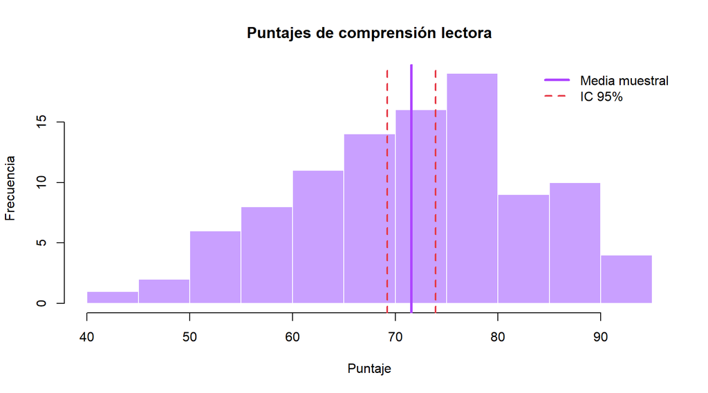

```r
hist(datos,
     breaks = 12,
     col = lila,
     border = "white",
     main = "Puntajes de comprensión lectora",
     xlab = "Puntaje",
     ylab = "Frecuencia")

abline(v = xbar, col = morado, lwd = 3)
abline(v = ic, col = rosa, lwd = 2, lty = 2)

legend("topright",
       legend = c("Media muestral", "IC 95%"),
       col = c(morado, rosa),
       lty = c(1, 2),
       lwd = c(3, 2),
       bty = "n")
```

**Interpretación.** Con un nivel de confianza del 95 %, el intervalo calculado estima el promedio poblacional de comprensión lectora. Las líneas rojas representan los límites del intervalo y la línea morada indica la media muestral.

**NotaEjemplo 2. Media con varianza poblacional desconocida**

**Situación.** Se desea estimar el tiempo medio semanal de estudio autónomo de estudiantes universitarios. Se seleccionan aleatoriamente 25 estudiantes y se supone una población aproximadamente normal.

**Fórmula:**

$$IC_{\mu}=\overline{x}\pm t_{1-\alpha/2,n-1}
\frac{S}{\sqrt{n}}$$

**Procedimiento y sustitución:**

**Ver código**

```r
set.seed(202)

n <- 25
datos <- rnorm(n, 8.4, 2.5)

xbar <- mean(datos)
s <- sd(datos)
gl <- n-1
tcrit <- qt(1-alpha/2, gl)

margen <- tcrit*s/sqrt(n)
ic <- intervalo(xbar, margen)

paso(sprintf(
  "\\bar{x}=%.3f,\\quad S=%.3f,\\quad n=%d",
  xbar, s, n
))
```

$$\bar{x}=8.636,\quad S=2.464,\quad n=25$$

**Ver código**

```r
paso(sprintf(
  "t_{0.975,%d}=%.3f",
  gl, tcrit
))
```

$$t_{0.975,24}=2.064$$

**Ver código**

```r
paso(sprintf(
  "IC_{95\\%%}=%.3f\\pm%.3f\\left(\\frac{%.3f}{\\sqrt{%d}}\\right)",
  xbar, tcrit, s, n
))
```

$$IC_{95\%}=8.636\pm2.064\left(\frac{2.464}{\sqrt{25}}\right)$$

**Ver código**

```r
paso(sprintf(
  "IC_{95\\%%}=%.3f\\pm%.3f",
  xbar, margen
))
```

$$IC_{95\%}=8.636\pm1.017$$

**Ver código**

```r
paso(sprintf(
  "\\boxed{IC_{95\\%%}=[%.3f,\\ %.3f]}",
  ic[1], ic[2]
))
```

$$\boxed{IC_{95\%}=[7.619,\ 9.653]}$$

**Ver código**

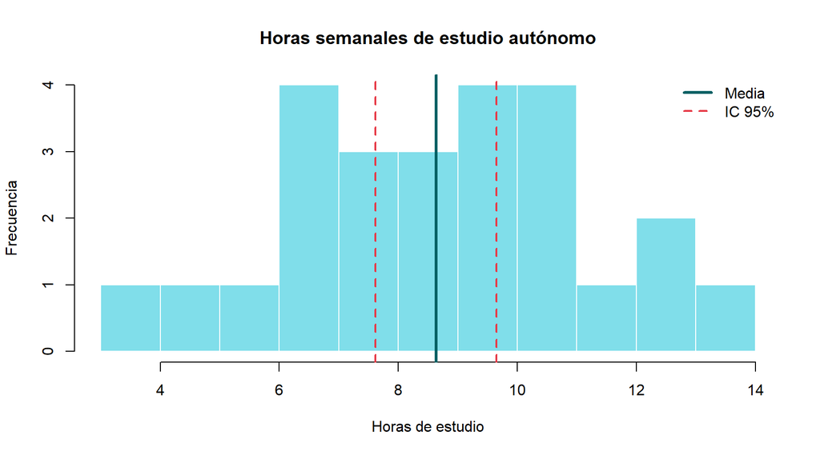

```r
hist(datos,
     breaks = 8,
     col = "#80DEEA",
     border = "white",
     main = "Horas semanales de estudio autónomo",
     xlab = "Horas de estudio",
     ylab = "Frecuencia")

abline(v = xbar, col = "#006064", lwd = 3)
abline(v = ic, col = rosa, lwd = 2, lty = 2)

legend("topright",
       legend = c("Media", "IC 95%"),
       col = c("#006064", rosa),
       lwd = c(3, 2),
       lty = c(1, 2),
       bty = "n")
```

**Interpretación.** El intervalo estima, con un nivel de confianza del 95 %, el promedio poblacional de horas semanales dedicadas al estudio autónomo. Se utiliza la distribución t de Student porque la desviación estándar poblacional es desconocida.

**NotaEjemplo 3. Proporción poblacional**

**Situación.** Una institución educativa desea estimar la proporción de estudiantes que utilizan semanalmente la biblioteca digital. Se encuesta aleatoriamente a 200 estudiantes.

**Fórmula:**

$$\widehat{p}=\frac{x}{n}$$

$$IC_p=\widehat{p}\pm z_{1-\alpha/2}
\sqrt{\frac{\widehat{p}(1-\widehat{p})}{n}}$$

**Procedimiento y sustitución:**

**Ver código**

```r
set.seed(303)

n <- 200
datos <- rbinom(n, 1, 0.75)

exitos <- sum(datos)
phat <- exitos/n

margen <- z*sqrt(phat*(1-phat)/n)
ic <- intervalo(phat, margen)

paso(sprintf(
  "\\widehat{p}=\\frac{%d}{%d}=%.3f",
  exitos, n, phat
))
```

$$\widehat{p}=\frac{147}{200}=0.735$$

**Ver código**

```r
paso(sprintf(
  "IC_{95\\%%}=%.3f\\pm1.960\\sqrt{\\frac{%.3f(1-%.3f)}{%d}}",
  phat, phat, phat, n
))
```

$$IC_{95\%}=0.735\pm1.960\sqrt{\frac{0.735(1-0.735)}{200}}$$

**Ver código**

```r
paso(sprintf(
  "IC_{95\\%%}=%.3f\\pm%.3f",
  phat, margen
))
```

$$IC_{95\%}=0.735\pm0.061$$

**Ver código**

```r
paso(sprintf(
  "\\boxed{IC_{95\\%%}=[%.2f\\%%,\\ %.2f\\%%]}",
  100*ic[1], 100*ic[2]
))
```

$$\boxed{IC_{95\%}=[67.38\%,\ 79.62\%]}$$

**Ver código**

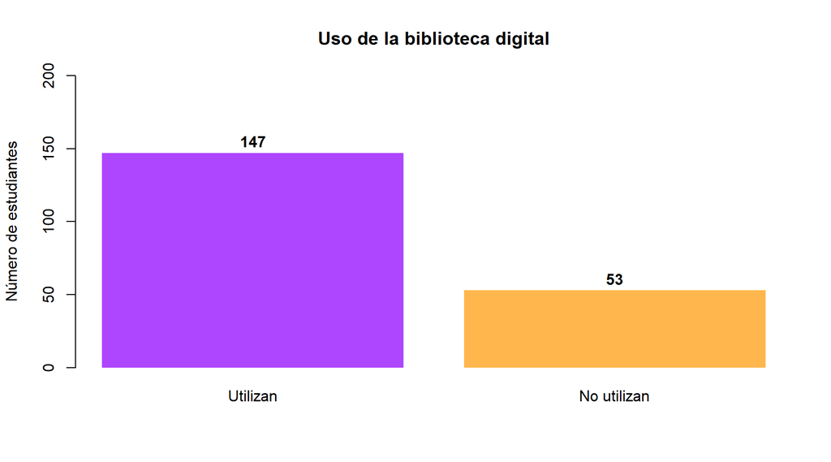

```r
frecuencias <- c(exitos, n-exitos)

bp <- barplot(frecuencias,
              names.arg = c("Utilizan", "No utilizan"),
              col = c(morado, "#FFB74D"),
              border = NA,
              ylim = c(0, n),
              main = "Uso de la biblioteca digital",
              ylab = "Número de estudiantes")

text(bp, frecuencias+8,
     labels = frecuencias,
     font = 2)
```

**Interpretación.** El intervalo del 95 % estima la proporción poblacional de estudiantes que utilizan la biblioteca digital semanalmente. El gráfico muestra las frecuencias observadas en la muestra.

**NotaEjemplo 4. Varianza poblacional**

**Situación.** Se desea estimar la variabilidad de los puntajes de matemáticas de una población estudiantil. Se seleccionan aleatoriamente 20 estudiantes y se supone normalidad poblacional.

**Fórmula:**

$$IC_{\sigma^2}=
\left[
\frac{(n-1)S^2}{\chi^2_{1-\alpha/2,n-1}},
\frac{(n-1)S^2}{\chi^2_{\alpha/2,n-1}}
\right]$$

**Procedimiento y sustitución:**

**Ver código**

```r
set.seed(404)

n <- 20
datos <- rnorm(n, 75, 8)

s2 <- var(datos)
gl <- n-1

chi_inf <- qchisq(alpha/2, gl)
chi_sup <- qchisq(1-alpha/2, gl)

ic <- c(
  inferior = gl*s2/chi_sup,
  superior = gl*s2/chi_inf
)

paso(sprintf(
  "S^2=%.3f,\\quad n=%d,\\quad gl=%d",
  s2, n, gl
))
```

$$S^2=49.215,\quad n=20,\quad gl=19$$

**Ver código**

```r
paso(sprintf(
  "\\chi^2_{0.025,%d}=%.3f,\\quad \\chi^2_{0.975,%d}=%.3f",
  gl, chi_inf, gl, chi_sup
))
```

$$\chi^2_{0.025,19}=8.907,\quad \chi^2_{0.975,19}=32.852$$

**Ver código**

```r
paso(sprintf(
  "IC_{95\\%%}=\\left[\\frac{%d(%.3f)}{%.3f},\\ \\frac{%d(%.3f)}{%.3f}\\right]",
  gl, s2, chi_sup, gl, s2, chi_inf
))
```

$$IC_{95\%}=\left[\frac{19(49.215)}{32.852},\ \frac{19(49.215)}{8.907}\right]$$

**Ver código**

```r
paso(sprintf(
  "\\boxed{IC_{95\\%%}=[%.3f,\\ %.3f]}",
  ic[1], ic[2]
))
```

$$\boxed{IC_{95\%}=[28.463,\ 104.988]}$$

**Ver código**

```r
paso(sprintf(
  "IC_{\\sigma,95\\%%}=[%.3f,\\ %.3f]",
  sqrt(ic[1]), sqrt(ic[2])
))
```

$$IC_{\sigma,95\%}=[5.335,\ 10.246]$$

**Ver código**

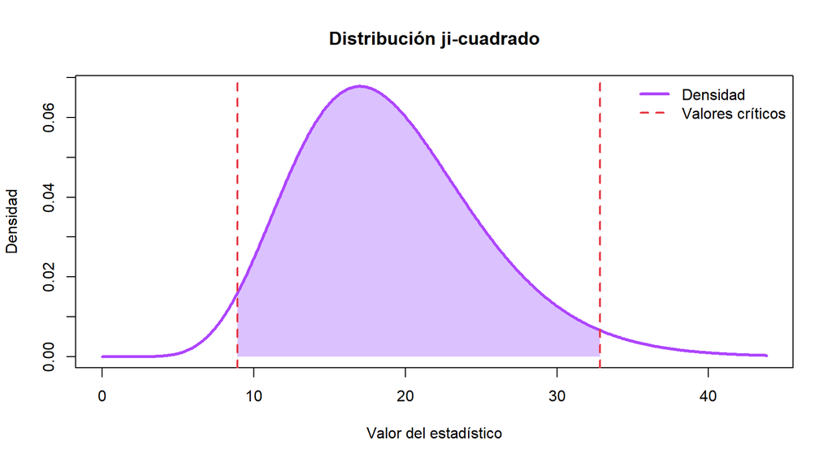

```r
x <- seq(0, qchisq(0.999, gl), length.out = 600)
y <- dchisq(x, gl)

plot(x, y, type = "l",
     col = morado, lwd = 3,
     main = "Distribución ji-cuadrado",
     xlab = "Valor del estadístico",
     ylab = "Densidad")

zona <- x >= chi_inf & x <= chi_sup

polygon(c(chi_inf, x[zona], chi_sup),
        c(0, y[zona], 0),
        col = adjustcolor(lila, alpha.f = 0.65),
        border = NA)

lines(x, y, col = morado, lwd = 3)

abline(v = c(chi_inf, chi_sup),
       col = rosa, lwd = 2, lty = 2)

legend("topright",
       legend = c("Densidad", "Valores críticos"),
       col = c(morado, rosa),
       lwd = c(3, 2),
       lty = c(1, 2),
       bty = "n")
```

**Interpretación.** El intervalo estima la varianza poblacional de los puntajes, expresada en puntos cuadrados. La raíz cuadrada de sus extremos proporciona un intervalo para la desviación estándar.

La región sombreada representa el 95 % central de la distribución ji-cuadrado utilizada en el procedimiento.

**NotaEjemplo 5. Diferencia de medias con varianzas conocidas**

**Situación.** Se comparan los puntajes de matemáticas de dos instituciones independientes. Se consideran conocidas las desviaciones estándar poblacionales: 10 puntos en A y 9 puntos en B.

**Fórmula:**

$$IC_{\mu_1-\mu_2}=
(\overline{x}_1-\overline{x}_2)
\pm z_{1-\alpha/2}
\sqrt{\frac{\sigma_1^2}{n_1}+\frac{\sigma_2^2}{n_2}}$$

**Procedimiento y sustitución:**

**Ver código**

```r
set.seed(505)

n1 <- 64
n2 <- 81
sigma1 <- 10
sigma2 <- 9

A <- rnorm(n1, 78, sigma1)
B <- rnorm(n2, 74, sigma2)

x1 <- mean(A)
x2 <- mean(B)

dif <- x1-x2
margen <- z*sqrt(sigma1^2/n1+sigma2^2/n2)

ic <- intervalo(dif, margen)

paso(sprintf(
  "\\bar{x}_1=%.3f,\\quad \\bar{x}_2=%.3f",
  x1, x2
))
```

$$\bar{x}_1=76.248,\quad \bar{x}_2=74.029$$

**Ver código**

```r
paso(sprintf(
  "\\bar{x}_1-\\bar{x}_2=%.3f-%.3f=%.3f",
  x1, x2, dif
))
```

$$\bar{x}_1-\bar{x}_2=76.248-74.029=2.219$$

**Ver código**

```r
paso(sprintf(
  "IC_{95\\%%}=%.3f\\pm1.960\\sqrt{\\frac{%d}{%d}+\\frac{%d}{%d}}",
  dif, sigma1^2, n1, sigma2^2, n2
))
```

$$IC_{95\%}=2.219\pm1.960\sqrt{\frac{100}{64}+\frac{81}{81}}$$

**Ver código**

```r
paso(sprintf(
  "IC_{95\\%%}=%.3f\\pm%.3f",
  dif, margen
))
```

$$IC_{95\%}=2.219\pm3.137$$

**Ver código**

```r
paso(sprintf(
  "\\boxed{IC_{95\\%%}=[%.3f,\\ %.3f]}",
  ic[1], ic[2]
))
```

$$\boxed{IC_{95\%}=[-0.918,\ 5.357]}$$

**Ver código**

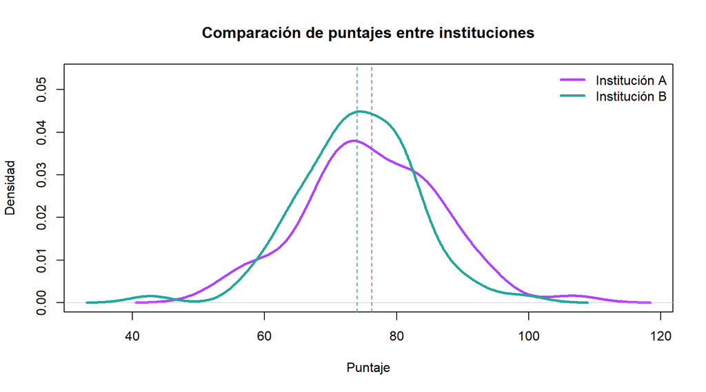

```r
dA <- density(A)
dB <- density(B)

plot(dA,
     col = morado, lwd = 3,
     xlim = range(c(dA$x, dB$x)),
     ylim = c(0, max(dA$y,dB$y)*1.2),
     main = "Comparación de puntajes entre instituciones",
     xlab = "Puntaje",
     ylab = "Densidad")

lines(dB, col = turquesa, lwd = 3)

abline(v = x1, col = morado, lty = 2)
abline(v = x2, col = turquesa, lty = 2)

legend("topright",
       legend = c("Institución A", "Institución B"),
       col = c(morado, turquesa),
       lwd = 3,
       bty = "n")
```

**Interpretación.** El intervalo del 95 % estima la diferencia entre las medias poblacionales de las dos instituciones. Si contiene cero, no se descarta una diferencia nula al nivel bilateral del 5 %. Si no lo contiene, existe evidencia estadística de una diferencia.

**NotaEjemplo 6. Diferencia de medias con varianzas desconocidas e iguales**

**Situación.** Se comparan dos metodologías de enseñanza aplicadas a grupos independientes. Se supone que las varianzas poblacionales son iguales, aunque desconocidas.

**Fórmulas:**

$$S_p^2=
\frac{(n_1-1)S_1^2+(n_2-1)S_2^2}
{n_1+n_2-2}$$

$$IC_{\mu_1-\mu_2}=
(\overline{x}_1-\overline{x}_2)
\pm t_{1-\alpha/2,n_1+n_2-2}
S_p\sqrt{\frac1{n_1}+\frac1{n_2}}$$

**Procedimiento y sustitución:**

**Ver código**

```r
set.seed(606)

n1 <- 30
n2 <- 28

A <- rnorm(n1, 82, 8)
B <- rnorm(n2, 77, 8)

x1 <- mean(A)
x2 <- mean(B)
s1 <- sd(A)
s2 <- sd(B)

gl <- n1+n2-2

sp2 <- ((n1-1)*s1^2+(n2-1)*s2^2)/gl
sp <- sqrt(sp2)

tcrit <- qt(1-alpha/2, gl)
dif <- x1-x2

margen <- tcrit*sp*sqrt(1/n1+1/n2)
ic <- intervalo(dif, margen)

paso(sprintf(
  "\\bar{x}_1=%.3f,\\quad \\bar{x}_2=%.3f",
  x1, x2
))
```

$$\bar{x}_1=82.823,\quad \bar{x}_2=74.457$$

**Ver código**

```r
paso(sprintf(
  "S_p^2=\\frac{%d(%.3f)^2+%d(%.3f)^2}{%d}=%.3f",
  n1-1, s1, n2-1, s2, gl, sp2
))
```

$$S_p^2=\frac{29(8.523)^2+27(8.579)^2}{56}=73.104$$

**Ver código**

```r
paso(sprintf(
  "IC_{95\\%%}=%.3f\\pm%.3f(%.3f)\\sqrt{\\frac1{%d}+\\frac1{%d}}",
  dif, tcrit, sp, n1, n2
))
```

$$IC_{95\%}=8.367\pm2.003(8.550)\sqrt{\frac1{30}+\frac1{28}}$$

**Ver código**

```r
paso(sprintf(
  "IC_{95\\%%}=%.3f\\pm%.3f",
  dif, margen
))
```

$$IC_{95\%}=8.367\pm4.501$$

**Ver código**

```r
paso(sprintf(
  "\\boxed{IC_{95\\%%}=[%.3f,\\ %.3f]}",
  ic[1], ic[2]
))
```

$$\boxed{IC_{95\%}=[3.866,\ 12.867]}$$

**Ver código**

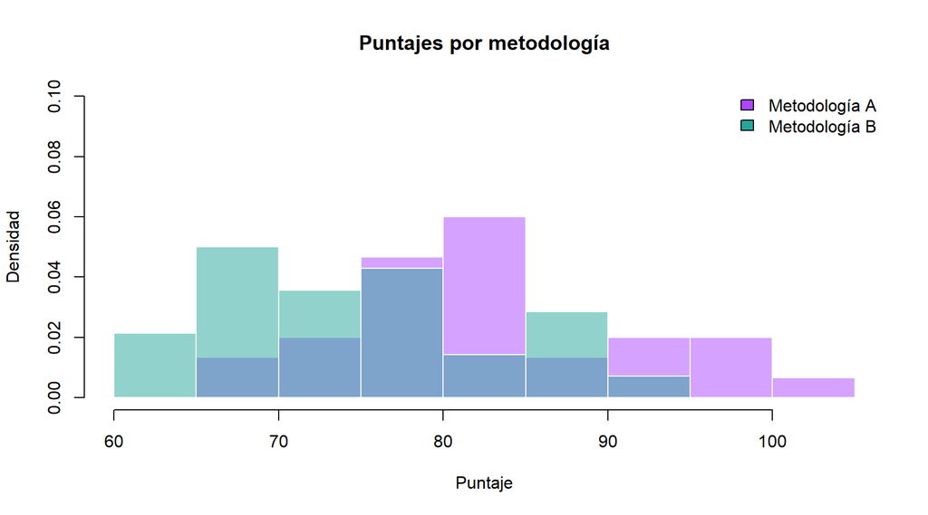

```r
cortes <- pretty(range(c(A,B)), n = 10)

hist(A,
     breaks = cortes,
     freq = FALSE,
     col = adjustcolor(morado, alpha.f = 0.5),
     border = "white",
     main = "Puntajes por metodología",
     xlab = "Puntaje",
     ylab = "Densidad",
     ylim = c(0, 0.10))

hist(B,
     breaks = cortes,
     freq = FALSE,
     col = adjustcolor(turquesa, alpha.f = 0.5),
     border = "white",
     add = TRUE)

legend("topright",
       legend = c("Metodología A", "Metodología B"),
       fill = c(morado, turquesa),
       bty = "n")
```

**Interpretación.** El intervalo del 95 % estima la diferencia entre los promedios poblacionales de ambas metodologías. Se utiliza una varianza agrupada bajo el supuesto de igualdad de varianzas poblacionales.

**NotaEjemplo 7. Diferencia de medias con varianzas distintas (Welch)**

**Situación.** Se compara el rendimiento en resolución de problemas de dos colegios independientes. Las varianzas poblacionales son desconocidas y no se supone que sean iguales.

**Fórmulas:**

$$IC_{\mu_1-\mu_2}=
(\overline{x}_1-\overline{x}_2)
\pm t_{1-\alpha/2,\nu}
\sqrt{\frac{S_1^2}{n_1}+\frac{S_2^2}{n_2}}$$

$$\nu\approx
\frac{(S_1^2/n_1+S_2^2/n_2)^2}
{\dfrac{(S_1^2/n_1)^2}{n_1-1}
+\dfrac{(S_2^2/n_2)^2}{n_2-1}}$$

**Procedimiento y sustitución:**

**Ver código**

```r
set.seed(707)

n1 <- 25
n2 <- 35

A <- rnorm(n1, 85, 12)
B <- rnorm(n2, 79, 7)

x1 <- mean(A)
x2 <- mean(B)

s1 <- sd(A)
s2 <- sd(B)

a <- s1^2/n1
b <- s2^2/n2

nu <- (a+b)^2/(a^2/(n1-1)+b^2/(n2-1))

tcrit <- qt(1-alpha/2, nu)

dif <- x1-x2
margen <- tcrit*sqrt(a+b)

ic <- intervalo(dif, margen)

paso(sprintf(
  "\\bar{x}_1=%.3f,\\quad \\bar{x}_2=%.3f",
  x1, x2
))
```

$$\bar{x}_1=86.212,\quad \bar{x}_2=79.674$$

**Ver código**

```r
paso(sprintf(
  "\\nu=\\frac{(%.3f+%.3f)^2}{\\frac{(%.3f)^2}{%d}+\\frac{(%.3f)^2}{%d}}=%.3f",
  a, b, a, n1-1, b, n2-1, nu
))
```

$$\nu=\frac{(5.750+1.152)^2}{\frac{(5.750)^2}{24}+\frac{(1.152)^2}{34}}=33.624$$

**Ver código**

```r
paso(sprintf(
  "IC_{95\\%%}=%.3f\\pm%.3f\\sqrt{\\frac{(%.3f)^2}{%d}+\\frac{(%.3f)^2}{%d}}",
  dif, tcrit, s1, n1, s2, n2
))
```

$$IC_{95\%}=6.538\pm2.033\sqrt{\frac{(11.989)^2}{25}+\frac{(6.349)^2}{35}}$$

**Ver código**

```r
paso(sprintf(
  "IC_{95\\%%}=%.3f\\pm%.3f",
  dif, margen
))
```

$$IC_{95\%}=6.538\pm5.341$$

**Ver código**

```r
paso(sprintf(
  "\\boxed{IC_{95\\%%}=[%.3f,\\ %.3f]}",
  ic[1], ic[2]
))
```

$$\boxed{IC_{95\%}=[1.197,\ 11.879]}$$

**Ver código**

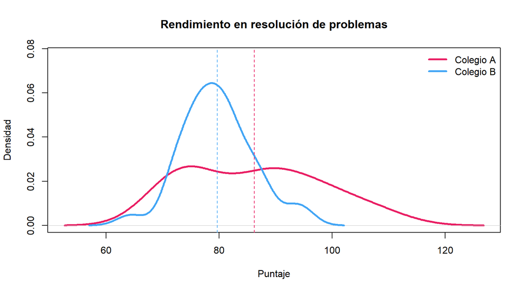

```r
dA <- density(A)
dB <- density(B)

plot(dA,
     col = "#E91E63",
     lwd = 3,
     xlim = range(c(dA$x,dB$x)),
     ylim = c(0,max(dA$y,dB$y)*1.2),
     main = "Rendimiento en resolución de problemas",
     xlab = "Puntaje",
     ylab = "Densidad")

lines(dB, col = azul, lwd = 3)

abline(v = x1, col = "#E91E63", lty = 2)
abline(v = x2, col = azul, lty = 2)

legend("topright",
       legend = c("Colegio A", "Colegio B"),
       col = c("#E91E63", azul),
       lwd = 3,
       bty = "n")
```

**Interpretación.** El intervalo del 95 % estima la diferencia de medias poblacionales sin imponer igualdad de varianzas. La gráfica permite comparar visualmente la dispersión de los puntajes de ambos colegios.

**NotaEjemplo 8. Diferencia de proporciones**

**Situación.** Se comparan las proporciones de estudiantes que entregan puntualmente sus proyectos en dos colegios. Se seleccionan muestras independientes de 120 estudiantes del colegio A y 100 del colegio B.

**Fórmula:**

$$IC_{p_1-p_2}=
(\widehat{p}_1-\widehat{p}_2)
\pm z_{1-\alpha/2}
\sqrt{
\frac{\widehat{p}_1(1-\widehat{p}_1)}{n_1}
+
\frac{\widehat{p}_2(1-\widehat{p}_2)}{n_2}
}$$

**Procedimiento y sustitución:**

**Ver código**

```r
set.seed(808)

n1 <- 120
n2 <- 100

A <- rbinom(n1, 1, 0.70)
B <- rbinom(n2, 1, 0.60)

e1 <- sum(A)
e2 <- sum(B)

p1 <- e1/n1
p2 <- e2/n2

dif <- p1-p2

se <- sqrt(p1*(1-p1)/n1+p2*(1-p2)/n2)
margen <- z*se

ic <- intervalo(dif, margen)

paso(sprintf(
  "\\widehat{p}_1=\\frac{%d}{%d}=%.3f",
  e1, n1, p1
))
```

$$\widehat{p}_1=\frac{88}{120}=0.733$$

**Ver código**

```r
paso(sprintf(
  "\\widehat{p}_2=\\frac{%d}{%d}=%.3f",
  e2, n2, p2
))
```

$$\widehat{p}_2=\frac{62}{100}=0.620$$

**Ver código**

```r
paso(sprintf(
  "IC_{95\\%%}=(%.3f-%.3f)\\pm1.960\\sqrt{\\frac{%.3f(1-%.3f)}{%d}+\\frac{%.3f(1-%.3f)}{%d}}",
  p1, p2, p1, p1, n1, p2, p2, n2
))
```

$$IC_{95\%}=(0.733-0.620)\pm1.960\sqrt{\frac{0.733(1-0.733)}{120}+\frac{0.620(1-0.620)}{100}}$$

**Ver código**

```r
paso(sprintf(
  "IC_{95\\%%}=%.3f\\pm%.3f",
  dif, margen
))
```

$$IC_{95\%}=0.113\pm0.124$$

**Ver código**

```r
paso(sprintf(
  "\\boxed{IC_{95\\%%}=[%.2f\\%%,\\ %.2f\\%%]}",
  100*ic[1], 100*ic[2]
))
```

$$\boxed{IC_{95\%}=[-1.04\%,\ 23.71\%]}$$

**Ver código**

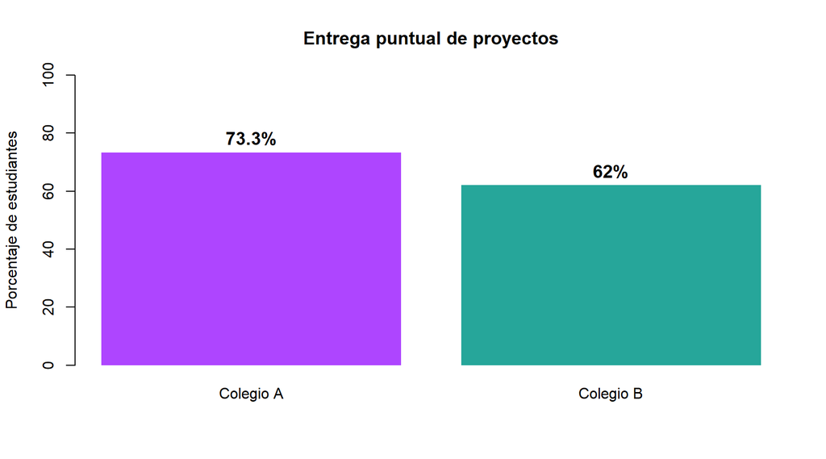

```r
porcentajes <- c(p1,p2)*100

bp <- barplot(porcentajes,
              names.arg = c("Colegio A", "Colegio B"),
              col = c(morado, turquesa),
              border = NA,
              ylim = c(0,100),
              main = "Entrega puntual de proyectos",
              ylab = "Porcentaje de estudiantes")

text(bp, porcentajes+5,
     labels = paste0(round(porcentajes,1),"%"),
     font = 2,
     cex = 1.2)
```

**Interpretación.** El intervalo del 95 % estima la diferencia entre las proporciones poblacionales de estudiantes que entregan puntualmente sus proyectos. Sus extremos se expresan en puntos porcentuales.

Si el intervalo contiene cero, no se descarta la igualdad de proporciones poblacionales al nivel bilateral del 5 %.

## 2.2 Conclusiones

La estimación puntual ofrece un valor representativo de un parámetro, mientras que los intervalos de confianza comunican la incertidumbre del muestreo. La elección correcta de la fórmula depende de **qué parámetro** se estima, de **cuántas poblaciones** se comparan, de la **independencia o apareamiento**, del conocimiento de las varianzas y de los **supuestos distribucionales**. En educación, estas herramientas permiten estudiar promedios, proporciones y variabilidad de resultados sin confundir diferencias estadísticas con efectos causales.